# Clasificación de expresión génica en Alzheimer y demencia vascular (GSE122063)

David Palomino Plantón

2026-06-30

# Carga y preprocesado de los datos

En primer lugar vamos a empezar cargar todas las librerias y los datos. También vamos a establecer una seed (set.seed) al principio que no volverá a cambiarse para facilitar la reproducibilidad de los resultados obtenidos.

```r
#Establecer una semilla
set.seed(123)
```

```r
# Instalación de librerías si no están instaladas
if (!requireNamespace("GEOquery", quietly = TRUE)) {
  BiocManager::install("GEOquery")
}
if (!requireNamespace("caret", quietly = TRUE)) {
  install.packages("caret")
}
if (!requireNamespace("DT", quietly = TRUE)) {
  install.packages("DT")
}
if (!requireNamespace("ggplot2", quietly = TRUE)) {
  install.packages("ggplot2")
}
if (!requireNamespace("patchwork", quietly = TRUE)) {
  install.packages("patchwork")
}
if (!requireNamespace("doParallel", quietly = TRUE)) {
  install.packages("doParallel")
}

# Carga de librerías necesarias

library(GEOquery)
library(caret)
library(DT)
library(ggplot2)
library(patchwork)
library(doParallel)

# Activamos el procesamiento en paralelo para acelerar los cálculos
registerDoParallel(cores = 4)

# Descarga del dataset desde GEO
gse    <- "GSE122063"
ngenes <- 5000

gset <- getGEO(gse, GSEMatrix = TRUE)
eset <- gset[[1]]

# Extraemos la matriz de expresión y los metadatos de las muestras
expr <- exprs(eset)
meta <- pData(eset)

# Definimos la variable respuesta a partir del diagnóstico del paciente
table(meta$`patient diagnosis:ch1`)
y <- meta$`patient diagnosis:ch1`

# Transponemos la matriz y nos quedamos con los genes de mayor varianza
X    <- t(expr)
vars <- apply(X, 2, var)
X    <- X[, order(vars, decreasing = TRUE)[1:ngenes]]

saveRDS(X,    "X.rds")
saveRDS(y,    "y.rds")
saveRDS(eset, "eset.rds")
```

vamos a unir la variable respuesta a los datos en los que tenemos los genes para generar el dataframe en el que ya lo tengamos todo junto.

```r
if (!requireNamespace("GEOquery", quietly = TRUE)) {
  BiocManager::install("GEOquery")
}
```

```
## Setting options('download.file.method.GEOquery'='auto')
```

```
## Setting options('GEOquery.inmemory.gpl'=FALSE)
```

```r
if (!requireNamespace("caret", quietly = TRUE)) {
  install.packages("caret")
}
if (!requireNamespace("DT", quietly = TRUE)) {
  install.packages("DT")
}
if (!requireNamespace("ggplot2", quietly = TRUE)) {
  install.packages("ggplot2")
}
if (!requireNamespace("patchwork", quietly = TRUE)) {
  install.packages("patchwork")
}
if (!requireNamespace("doParallel", quietly = TRUE)) {
  install.packages("doParallel")
}
library(GEOquery)
library(caret)
library(DT)
library(ggplot2)
library(patchwork)
library(doParallel)
registerDoParallel(cores = 4)

X    <- readRDS("X.rds")
y    <- readRDS("y.rds")
eset <- readRDS("eset.rds")

datos <- as.data.frame(X)
datos$y <- factor(y)
levels(datos$y) <- make.names(levels(datos$y))
```

# Análisis

## Análisis descriptivo y PCA

Se realiza un análisis descriptivo de los datos y un PCA exploratorio sobre la distribución de las variables del problema.

### Balance de clases e implicaciones

```r
dim(X)
```

[output not shown]

```r
table(y)
```

```
## y
## Alzheimer's disease             Control   Vascular dementia
##                  56                  44                  36
```

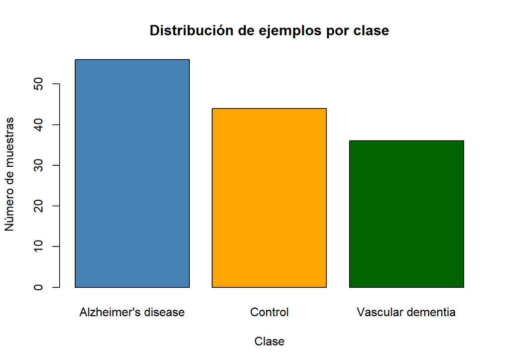

```r
barplot(table(y),
        col = c("steelblue", "orange", "darkgreen"),
        main = "Distribución de ejemplos por clase",
        xlab = "Clase",
        ylab = "Número de muestras")
```

Vemos que tenemos un dataset con 5000 genes y 136 ejemplos, los cuales están divididos en las clases Alzheimer’s disease, Control y Vascular dementia. La distribución de clases del dataset muestra que existen 56 muestras correspondientes a pacientes con Alzheimer, 36 con demencia y 44 controles. Por tanto, el dataset presenta un cierto desbalance entre clases, ya que el número de muestras no es igual para todas ellas. No obstante, este desbalance no es extremadamente acusado.

Este desbalance puede afectar al entrenamiento de los modelos de clasificación, ya que los algoritmos tienden a favorecer la clase mayoritaria durante el proceso de aprendizaje. Como consecuencia, el modelo podría obtener una alta precisión global pero un rendimiento peor en las clases menos representadas.

Dado que el número total de muestras es relativamente reducido, no resulta conveniente aplicar técnicas de downsampling, ya que eliminar ejemplos implicaría perder información valiosa. Por ello, una alternativa más adecuada es aplicar técnicas de oversampling, como el upsampling simple repitiendo ejemplos existentes, que permite equilibrar el número de ejemplos entre clases replicando muestras de las clases minoritarias. Asimismo, para evaluar los modelos se pueden utilizar métricas robustas frente al desbalance, como la balanced accuracy, que tiene en cuenta el rendimiento del modelo en cada clase por igual.

### Valores nulos

```r
sum(is.na(X))
```

```
## [1] 0
```

Se comprobó la presencia de valores nulos en la matriz de datos mediante la función is.na(). El resultado indica que no existen valores faltantes en el dataset. En caso de que existieran valores nulos, podrían tratarse mediante técnicas de imputación.

### Separabilidad de clases en el espacio del PCA

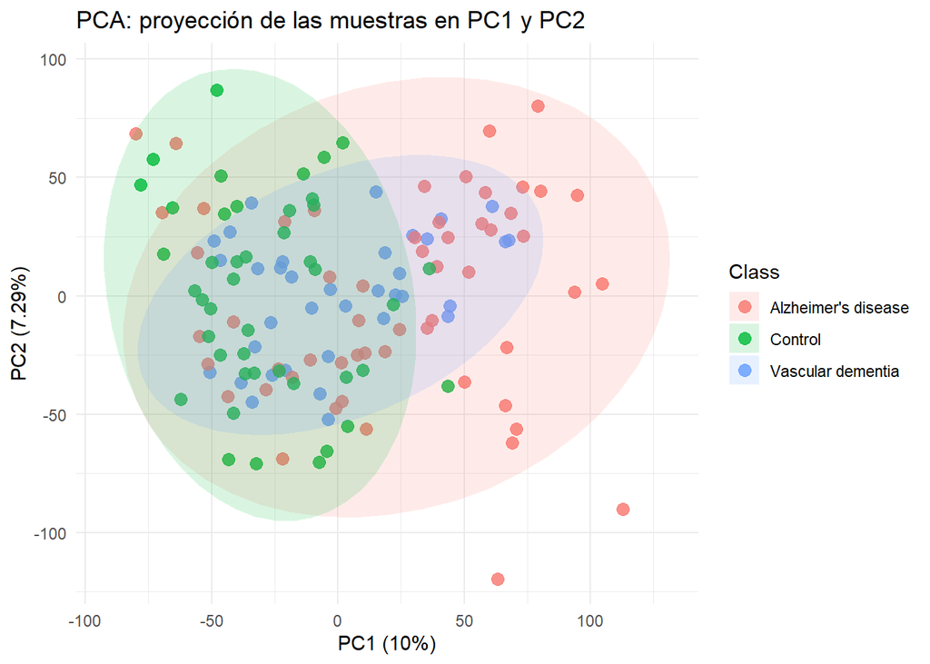

```r
# =========================
# PCA
# =========================

# Calcular PCA sobre los predictores
pca_res <- prcomp(X, center = TRUE, scale. = TRUE)

# Scores de las muestras
scores <- as.data.frame(pca_res$x)
scores$Class <- y

var_exp <- (pca_res$sdev^2) / sum(pca_res$sdev^2)

# =========================
# Visualización 1: PC1 vs PC2
# =========================

ggplot(scores, aes(x = PC1, y = PC2, color = Class, fill = Class)) +
  geom_point(size = 3, alpha = 0.8) +
  stat_ellipse(geom = "polygon", alpha = 0.15, color = NA) +
  theme_minimal() +
  labs(
    title = "PCA: proyección de las muestras en PC1 y PC2",
    x = paste0("PC1 (", round(var_exp[1] * 100, 2), "%)"),
    y = paste0("PC2 (", round(var_exp[2] * 100, 2), "%)")
  )
```

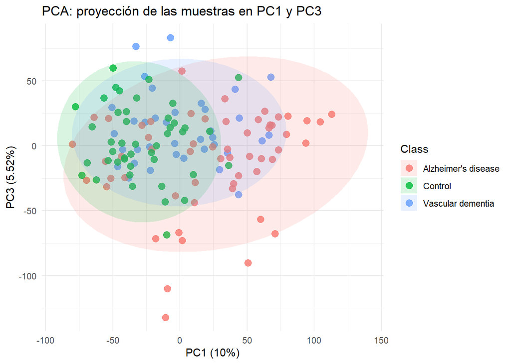

```r
# =========================
# Visualización 2: PC1 vs PC3
# =========================

ggplot(scores, aes(x = PC1, y = PC3, color = Class, fill = Class)) +
  geom_point(size = 3, alpha = 0.8) +
  stat_ellipse(geom = "polygon", alpha = 0.15, color = NA) +
  theme_minimal() +
  labs(
    title = "PCA: proyección de las muestras en PC1 y PC3",
    x = paste0("PC1 (", round(var_exp[1] * 100, 2), "%)"),
    y = paste0("PC3 (", round(var_exp[3] * 100, 2), "%)")
  )
```

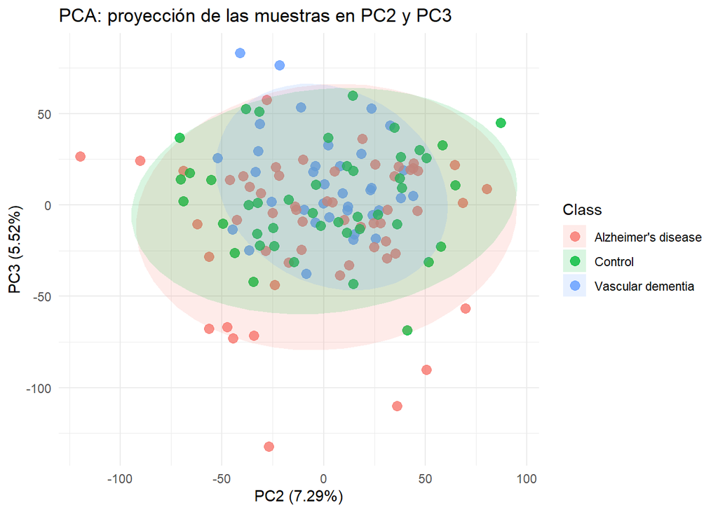

```r
# =========================
# Visualización 3: PC2 vs PC3
# =========================

ggplot(scores, aes(x = PC2, y = PC3, color = Class, fill = Class)) +
  geom_point(size = 3, alpha = 0.8) +
  stat_ellipse(geom = "polygon", alpha = 0.15, color = NA) +
  theme_minimal() +
  labs(
    title = "PCA: proyección de las muestras en PC2 y PC3",
    x = paste0("PC2 (", round(var_exp[2] * 100, 2), "%)"),
    y = paste0("PC3 (", round(var_exp[3] * 100, 2), "%)")
  )
```

La visualización de las muestras en el espacio de los tres primeros componentes principales muestra un solapamiento considerable entre las distintas clases, lo que indica que la separación entre controles, pacientes con Alzheimer y pacientes con demencia vascular no es completamente clara en una representación de baja dimensionalidad.

Sin embargo, se observa que muchos controles están más concentrados hacia valores negativos o cercanos a cero en PC1. Esto sugiere que el primer componente podría estar capturando parte de la variabilidad asociada a la enfermedad.

En conjunto, los tres primeros componentes principales muestran cierto grado de estructura en los datos, pero no permiten distinguir claramente entre las distintas clases. Esto sugiere que, aunque el dataset contiene cierta información discriminativa, será necesario emplear modelos de clasificación más complejos para diferenciar adecuadamente entre controles y los distintos tipos de enfermedad neurodegenerativa.

### Varianza explicada por los primeros componentes

```r
# =========================
# Varianza explicada
# =========================


# Tabla con varianza explicada y acumulada
tabla_varianza <- data.frame(
  Componente = paste0("PC", 1:length(var_exp)),
  Varianza_Explicada = var_exp,
  Varianza_Acumulada = cumsum(var_exp)
)

# Mostrar primeras componentes
head(tabla_varianza, 10)
```

```
##    Componente Varianza_Explicada Varianza_Acumulada
## 1         PC1         0.09996560          0.0999656
## 2         PC2         0.07290124          0.1728668
## 3         PC3         0.05517960          0.2280464
## 4         PC4         0.03354807          0.2615945
## 5         PC5         0.02903782          0.2906323
## 6         PC6         0.02130042          0.3119327
## 7         PC7         0.01813204          0.3300648
## 8         PC8         0.01688219          0.3469470
## 9         PC9         0.01556988          0.3625168
## 10       PC10         0.01338781          0.3759047
```

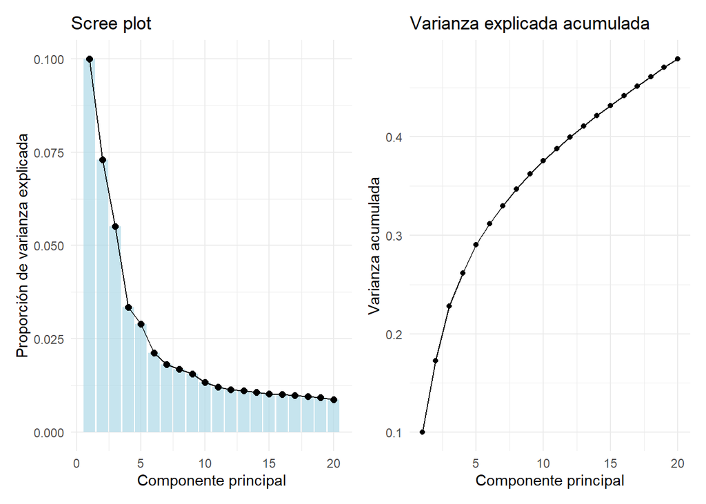

```r
# =========================
# Scree plot
# =========================
p1 <- ggplot(tabla_varianza[1:20, ], aes(x = seq_along(Varianza_Explicada), y = Varianza_Explicada)) +
  geom_col(fill = "lightblue", alpha = 0.7) +
  geom_line() +
  geom_point(size = 2) +
  theme_minimal() +
  labs(
    title = "Scree plot",
    x = "Componente principal",
    y = "Proporción de varianza explicada"
  )

# =========================
# Varianza acumulada
# =========================
p2 <- ggplot(tabla_varianza[1:20, ], aes(x = seq_along(Varianza_Acumulada), y = Varianza_Acumulada)) +
  geom_line() +
  geom_point() +
  theme_minimal() +
  labs(
    title = "Varianza explicada acumulada",
    x = "Componente principal",
    y = "Varianza acumulada"
  )

# ponerlos juntos
p1 + p2
```

Este resultado es coherente con la dificultad observada en la visualización del PCA, donde las tres clases no se separaban claramente en el espacio de baja dimensionalidad, y refuerza la necesidad de utilizar modelos de machine learning que trabajen con el espacio completo de variables en lugar de una representación reducida.

### Genes con mayor contribución por componente

Para ello, primero debemos hacer que en la tabla de resultados se muestren los nombres de los genes, ya que ahora mismo solo nos mostraría el identificador de la sonda del microarray.

```r
annot <- fData(eset)

loadings <- as.data.frame(pca_res$rotation)
loadings$Probe <- rownames(loadings)

loadings$Gene <- annot$`GENE_SYMBOL`[match(loadings$Probe, annot$ID)]
loadings <- loadings[!is.na(loadings$Gene) & loadings$Gene != "", ]
```

Ahora podemos crear la tabla de resultados incluyendo los nombres de cada uno de los 10 genes más influyentes en los dos primeros componentes.

```r
# Top 10 predictores para PC1
top_pc1 <- loadings[order(abs(loadings$PC1), decreasing = TRUE),
                    c("Gene", "PC1")][1:10, ]

# Top 10 predictores para PC2
top_pc2 <- loadings[order(abs(loadings$PC2), decreasing = TRUE),
                    c("Gene", "PC2")][1:10, ]

datatable(top_pc1,
          options = list(pageLength = 10, dom = "t"),
          rownames = FALSE)
```

| Gene | PC1 |
| --- | --- |
| MYT1L | -0.02081728928382903 |
| PNMA2 | -0.02063303816618866 |
| ENTPD3 | -0.0205359501415937 |
| TRIM37 | -0.02053536072283366 |
| SNORD17 | 0.02042887227665724 |
| PTTG1IP | 0.02035896695048277 |
| CD200 | -0.02029052869256466 |
| CAMTA1 | -0.02025194021612946 |
| CD200 | -0.02024664832917948 |
| GRIA4 | -0.02023636652752983 |

```r
datatable(top_pc2,
          options = list(pageLength = 10, dom = "t"),
          rownames = FALSE)
```

| Gene | PC2 |
| --- | --- |
| XLOC_011252 | 0.01734352672844244 |
| NLRC4 | 0.01661868468184719 |
| XLOC_l2_001640 | 0.01612428080564189 |
| XLOC_002530 | 0.01605281641010885 |
| IL2 | 0.01577473051069768 |
| IL1A | 0.01565620830018702 |
| XLOC_011407 | 0.0155889308064703 |
| XLOC_006433 | 0.01548755458653401 |
| CNGA2 | 0.01547403344623728 |
| XLOC_l2_010616 | 0.01544660912254744 |

Para interpretar los dos primeros componentes del PCA se han analizado los genes con mayor loading en cada componente, ya que son los que más contribuyen a explicar la variabilidad de los datos.

En conjunto, los resultados del PCA indican que existe una señal biológica real en los datos, especialmente en PC1, asociada a procesos conocidos de neurodegeneración. Sin embargo, la separación entre clases en el espacio PCA no es perfecta, lo que sugiere que el problema de clasificación no es trivial y que será necesario utilizar modelos de machine learning más complejos para discriminar adecuadamente entre las tres clases.

## Modelos de clasificación

### Creación y evaluación de modelos Random Forest y SVM

Se desarrollan modelos de ML multiclase para distinguir entre los tipos de condición del sujeto, con selección de modelos basada en la optimización de hiperparámetros mediante búsqueda en grid. El grid se diseña buscando un compromiso entre la amplitud del espacio de hiperparámetros explorado y un consumo razonable de recursos de computación. Se emplean modelos basados tanto en bosques aleatorios como en máquinas de vectores soporte.

En primer lugar, vamos a separar los datos en los conjuntos de train y de test para validación.

```r
trainIndex <- createDataPartition(datos$y,
                                  p = 0.66,
                                  list = FALSE,
                                  times = 1)
XTrain <- datos[trainIndex, ]
XTest  <- datos[-trainIndex, ]
```

El siguiente paso es crear el modelo de entrenamiento, con una validación cruzada de 10 pliegues:

```r
practica.traincontrol.cv.10 <- trainControl(
  method          = "cv",
  number          = 10,
  sampling        = "up",
  summaryFunction = multiClassSummary,
  classProbs      = TRUE,
  returnResamp    = "final",
  verboseIter     = FALSE,
  allowParallel   = TRUE
)
```

Como vimos anteriormente, existía cierto desbalanceo entre las clases existentes. Por ello, hemos usado el parámetro sampling = “up”; de esta manera sobre los datos de entrenamiento se aplicará un upsampling simple repitiendo ejemplos existentes hasta igualar el tamaño de las clases con la clase mayoritaria.

Para crear el modelo basado en random forest usaremos el paquete caret mediante el método ranger.

```r
rf_grid <- expand.grid(
  mtry          = c(50, 70, 150, 250),
  splitrule     = "gini",
  min.node.size = c(5, 7, 9)
)

ranger.cv.10 <- train(
  y ~ .,
  data       = XTrain,
  method     = "ranger",
  tuneGrid   = rf_grid,
  trControl  = practica.traincontrol.cv.10,
  importance = "impurity",
  metric     = "Mean_Balanced_Accuracy"
)

saveRDS(ranger.cv.10, "ranger.cv.10.rds")
```

Una vez creado nuestro modelo con random forest, vamos a proceder a crear el modelo con SVM

```r
svm_grid <- expand.grid(
  C     = c(0.01, 0.1, 1, 10, 100),
  sigma = c(0.00002, 0.0002, 0.002)
)

svm.cv.10 <- train(
  y ~ .,
  data       = XTrain,
  method     = "svmRadial",
  tuneGrid   = svm_grid,
  trControl  = practica.traincontrol.cv.10,
  preProcess = c("center", "scale"),
  metric     = "Mean_Balanced_Accuracy"
)

saveRDS(svm.cv.10, "svm.cv.10.rds")
```

Cargamos los modelos guardados en RDS:

```r
# Cargamos los modelos guardados
ranger.cv.10 <- readRDS("ranger.cv.10.rds")
svm.cv.10    <- readRDS("svm.cv.10.rds")
```

```r
#Resultados y mejor modelo RF
ranger.cv.10
```

```
## Random Forest
##
##   91 samples
## 5000 predictors
##    3 classes: 'Alzheimer.s.disease', 'Control', 'Vascular.dementia'
##
## No pre-processing
## Resampling: Cross-Validated (10 fold)
## Summary of sample sizes: 82, 81, 81, 83, 81, 82, ...
## Addtional sampling using up-sampling
##
## Resampling results across tuning parameters:
##
##   mtry  min.node.size  logLoss    AUC        prAUC      Accuracy   Kappa
##    50   5              0.6397412  0.9604762  0.6055291  0.8658333  0.7943166
##    50   7              0.6392784  0.9574074  0.6018948  0.8186111  0.7180109
##    50   9              0.6409182  0.9588095  0.6029398  0.8425000  0.7567358
##    70   5              0.6189760  0.9642593  0.6058102  0.8547222  0.7760866
##    70   7              0.6303322  0.9556614  0.5873148  0.8311111  0.7381743
##    70   9              0.6184774  0.9638889  0.6075463  0.8672222  0.7958165
##   150   5              0.5787672  0.9739021  0.6212731  0.8433333  0.7554976
##   150   7              0.5740683  0.9726190  0.6222685  0.9105556  0.8630556
##   150   9              0.5845627  0.9687169  0.6137269  0.8558333  0.7772409
##   250   5              0.5644627  0.9695899  0.6181019  0.8558333  0.7741655
##   250   7              0.5573813  0.9691005  0.6155556  0.8772222  0.8097358
##   250   9              0.5612863  0.9641534  0.6129630  0.8883333  0.8270556
##   Mean_F1    Mean_Sensitivity  Mean_Specificity  Mean_Pos_Pred_Value
##   0.8602116  0.8611111         0.9312698         0.8900000
##   0.8266902  0.8000000         0.9065079         0.8617284
##   0.8329894  0.8333333         0.9190476         0.8733333
##   0.8397090  0.8388889         0.9257143         0.8794444
##   0.8142063  0.8111111         0.9123810         0.8666667
##   0.8556349  0.8555556         0.9320635         0.8916667
##   0.8538801  0.8277778         0.9190476         0.8919753
##   0.9030423  0.9055556         0.9557143         0.9272222
##   0.8423016  0.8444444         0.9257143         0.8861111
##   0.8627866  0.8305556         0.9238095         0.9067901
##   0.8642857  0.8611111         0.9360317         0.9144444
##   0.8734127  0.8722222         0.9423810         0.9138889
##   Mean_Neg_Pred_Value  Mean_Precision  Mean_Recall  Mean_Detection_Rate
```

[output cut: 16 more lines]

```
##   0.8823016
##   0.8617460
##   0.8938095
##   0.8734127
##   0.9306349
##   0.8850794
##   0.8771825
##   0.8985714
##   0.9073016
##
## Tuning parameter 'splitrule' was held constant at a value of gini
## Mean_Balanced_Accuracy was used to select the optimal model using the
##  largest value.
## The final values used for the model were mtry = 150, splitrule = gini
##  and min.node.size = 7.
```

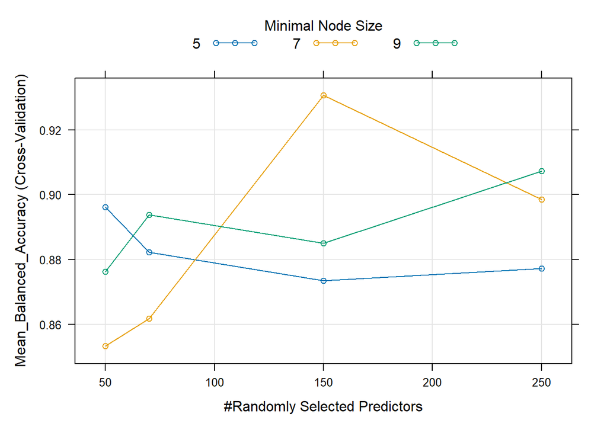

```r
plot(ranger.cv.10)
```

Al análizar los resultados del modelo vemos como la combinación más efectiva de hiperparámetros de entre todas las realizadas es mtry = 150 y min.node.size = 7

```r
#Resultados y mejor modelo SVM
svm.cv.10
```

```
## Support Vector Machines with Radial Basis Function Kernel
##
##   91 samples
## 5000 predictors
##    3 classes: 'Alzheimer.s.disease', 'Control', 'Vascular.dementia'
##
## Pre-processing: centered (5000), scaled (5000)
## Resampling: Cross-Validated (10 fold)
## Summary of sample sizes: 81, 82, 83, 82, 82, 81, ...
## Addtional sampling using up-sampling prior to pre-processing
##
## Resampling results across tuning parameters:
##
##   C      sigma  logLoss    AUC        prAUC      Accuracy   Kappa
##   1e-02  2e-05  0.9237277  0.6193386  0.3738442  0.4377778  0.1308272
##   1e-02  2e-04  0.9034268  0.6258333  0.3953522  0.4725000  0.1834522
##   1e-02  2e-03  1.1278465  0.6563757  0.4415046  0.3936111  0.0000000
##   1e-01  2e-05  0.9219796  0.8173942  0.4601670  0.5777778  0.3529039
##   1e-01  2e-04  0.8644724  0.8377116  0.4572553  0.6744444  0.4977546
##   1e-01  2e-03  1.1012835  0.8404233  0.5012401  0.4061111  0.0000000
##   1e+00  2e-05  0.7638303  0.8573545  0.4744858  0.6669444  0.4853017
##   1e+00  2e-04  0.6107262  0.9279101  0.5563790  0.7516667  0.6127977
##   1e+00  2e-03  1.0981011  0.8884788  0.5312897  0.4061111  0.0000000
##   1e+01  2e-05  0.3951132  0.9691402  0.6068485  0.8597222  0.7819793
##   1e+01  2e-04  0.5454435  0.9422090  0.5787996  0.8050000  0.6928650
##   1e+01  2e-03  1.1033135  0.9020106  0.5395007  0.4061111  0.0000000
##   1e+02  2e-05  0.3615234  0.9828307  0.6220569  0.8819444  0.8162553
##   1e+02  2e-04  0.5339252  0.9409392  0.5797007  0.8150000  0.7065905
##   1e+02  2e-03  1.0997069  0.8960582  0.5341700  0.4061111  0.0000000
##   Mean_F1    Mean_Sensitivity  Mean_Specificity  Mean_Pos_Pred_Value
##   0.5859347  0.4250000         0.7106349         0.5534722
##   0.5978175  0.4388889         0.7271429         0.5087302
##         NaN  0.3333333         0.6666667               NaN
##   0.5704586  0.5500000         0.7847619         0.6047619
##   0.7026077  0.6500000         0.8330159         0.6500000
##         NaN  0.3333333         0.6666667               NaN
##   0.6781415  0.6527778         0.8279365         0.7012346
##   0.7276602  0.7194444         0.8695238         0.8006173
##         NaN  0.3333333         0.6666667               NaN
##   0.8609347  0.8333333         0.9268254         0.8838889
```

[output cut: 26 more lines]

```
##   0.7415079
##   0.5000000
##   0.7403571
##   0.7944841
##   0.5000000
##   0.8800794
##   0.8325794
##   0.5000000
##   0.8977381
##   0.8381349
##   0.5000000
##
## Mean_Balanced_Accuracy was used to select the optimal model using the
##  largest value.
## The final values used for the model were sigma = 2e-05 and C = 100.
```

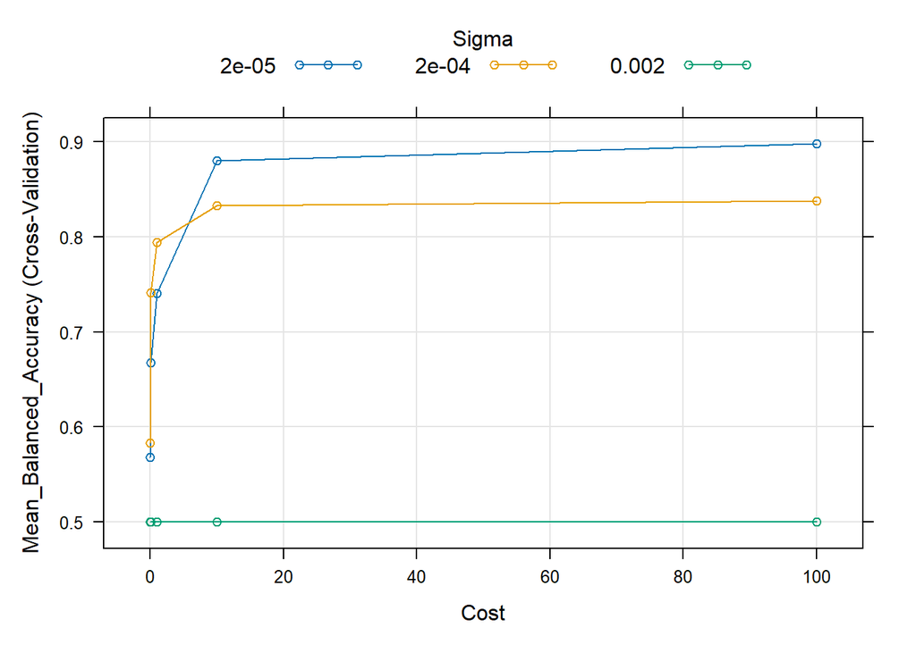

```r
plot(svm.cv.10)
```

En los resultados del modelo se observa como el mejor modelo es aquel resultante de la combinación de hiperparámetros sigma = 2e-05 y C = 100.

También se aprecia que con sigma = 0.002 no se observa que el balanced accuracy se modifique para ningún valor de C, por tanto podemos deducir que sigma = 0.002 es un valor demasiado alto del hiperparámetro para los datos de este problema.

## Resultados e interpretación

### Estrategia de optimización de hiperparámetros

Random Forest

Para el modelo basado en random forest se han explorado tres hiperparámetros:

- mtry (50, 70, 150, 250): número de genes candidatos que se evalúan en cada split del árbol. El valor teórico mínimo recomendado para clasificación es √p = √5000 ≈ 70, por lo que se incluye este valor como referencia y se exploran valores superiores hasta 250. Usar valores más altos es conveniente en este problema porque la mayoría de los 5000 genes son probablemente irrelevantes, por lo que aumentar mtry incrementa la probabilidad de incluir genes informativos en cada división.
- min.node.size (5, 7, 9): tamaño mínimo que debe tener un nodo para poder dividirse. Se prueban únicamente valores impares entre 5 y 9 porque con tan pocas muestras valores inferiores provocarían sobreajuste al seguir ramificando nodos con muy pocos ejemplos, y valores superiores generarían árboles demasiado simples con riesgo de infraajuste. Se prueban valores impares para evitar que se produzcan empates al votar la clase mayoritaria en ese nodo, lo que hace las decisiones del árbol más deterministas.
- splitrule (gini): criterio de división de los nodos, fijado a gini ya que es el estándar para problemas de clasificación multiclase.

SVM

Para el modelo basado en SVM se han explorado los siguientes hiperparámetros:

- C (0.01, 0.1, 1, 10, 100): parámetro de penalización que controla el equilibrio entre maximizar el margen de separación y minimizar los errores de clasificación. Valores bajos de C permiten más errores pero generan modelos más generales, mientras que valores altos penalizan más los errores con riesgo de sobreajuste. Se exploran cinco valores en escala logarítmica para cubrir un amplio rango de comportamientos.
- sigma (0.00002, 0.0002, 0.002): parámetro del kernel radial que controla el radio de influencia de cada muestra. Se toma como valor central el teórico 1/p = 1/5000 = 0.0002, explorando un orden de magnitud por encima y por debajo en escala logarítmica, que es la estrategia estándar para este hiperparámetro en problemas de alta dimensionalidad.

El grid de 5×3 = 15 combinaciones supone un coste computacional asumible con validación cruzada de 10 pliegues, cubriendo a la vez modelos simples (C bajo, sigma bajo) y más complejos (C alto, sigma alto).

### Métricas de rendimiento y estrategia de remuestreo

Como métrica principal para seleccionar el mejor modelo se ha utilizado la Balanced Accuracy (Mean_Balanced_Accuracy), que calcula la media de la sensibilidad de cada clase. Esta métrica es más adecuada que la Accuracy simple en problemas multiclase con cierto desbalance, ya que penaliza por igual los errores en todas las clases independientemente de su tamaño.

La estrategia de remuestreo utilizada es validación cruzada de 10 pliegues, que divide los datos de entrenamiento en 10 subconjuntos, entrenando el modelo en 9 de ellos y validando en el restante de forma rotativa. Esto proporciona una estimación más fiable del rendimiento que una simple partición train/test, ya que todos los datos participan tanto en el entrenamiento como en la validación. Adicionalmente, en cada fold se aplica upsampling sobre los datos de entrenamiento para compensar el desbalance de clases.

El motivo por el que se ha seleccionado Balanced Accuracy es porque aunque se aplica upsampling en el entrenamiento, el fold de validación mantiene la distribución original desbalanceada, por lo que esta métrica es más robusta para comparar modelos.

### Comparación y selección de modelos

Para determinar el mejor algoritmo se han analizado los resultados obtenidos durante la validación cruzada y en el conjunto de test.

```r
#Comparación entre mejores modelos
modelos <- list(
  RF  = ranger.cv.10,
  SVM = svm.cv.10
)

practica.resample <- resamples(modelos)
summary(practica.resample)
```

```
##
## Call:
## summary.resamples(object = practica.resample)
##
## Models: RF, SVM
## Number of resamples: 10
##
## Accuracy
##     Min.   1st Qu.    Median      Mean   3rd Qu. Max. NA's
## RF  0.75 0.8888889 0.9000000 0.9105556 1.0000000    1    0
## SVM 0.80 0.8784722 0.8888889 0.8819444 0.8888889    1    0
##
## AUC
##          Min.   1st Qu.    Median      Mean 3rd Qu. Max. NA's
## RF  0.8333333 0.9732143 0.9888889 0.9726190       1    1    0
## SVM 0.9314815 0.9662698 1.0000000 0.9828307       1    1    0
##
## Kappa
##          Min.   1st Qu.    Median      Mean   3rd Qu. Max. NA's
## RF  0.6097561 0.8309748 0.8484501 0.8630556 1.0000000    1    0
## SVM 0.6875000 0.8086585 0.8217647 0.8162553 0.8325472    1    0
##
## logLoss
##          Min.   1st Qu.    Median      Mean   3rd Qu.      Max. NA's
## RF  0.4663468 0.5285089 0.5518990 0.5740683 0.5970407 0.8029131    0
## SVM 0.2353979 0.2908758 0.3681709 0.3615234 0.4303251 0.4787287    0
##
## Mean_Balanced_Accuracy
##          Min.   1st Qu.    Median      Mean   3rd Qu. Max. NA's
## RF  0.7944444 0.9166667 0.9275794 0.9306349 1.0000000    1    0
## SVM 0.8333333 0.8833333 0.8861111 0.8977381 0.9166667    1    0
##
## Mean_Detection_Rate
##          Min.   1st Qu.    Median      Mean   3rd Qu.      Max. NA's
## RF  0.2500000 0.2962963 0.3000000 0.3035185 0.3333333 0.3333333    0
## SVM 0.2666667 0.2928241 0.2962963 0.2939815 0.2962963 0.3333333    0
##
## Mean_F1
##          Min.   1st Qu.    Median      Mean   3rd Qu. Max. NA's
## RF  0.7380952 0.8714286 0.9005291 0.9030423 1.0000000    1    0
```

[output cut: 21 more lines]

```
##
## Mean_Sensitivity
##          Min.   1st Qu.    Median      Mean   3rd Qu. Max. NA's
## RF  0.7222222 0.8888889 0.9027778 0.9055556 1.0000000    1    0
## SVM 0.7777778 0.8333333 0.8333333 0.8583333 0.8888889    1    0
##
## Mean_Specificity
##          Min.   1st Qu.    Median      Mean   3rd Qu. Max. NA's
## RF  0.8666667 0.9444444 0.9523810 0.9557143 1.0000000    1    0
## SVM 0.8888889 0.9333333 0.9388889 0.9371429 0.9444444    1    0
##
## prAUC
##         Min.   1st Qu.    Median      Mean   3rd Qu.      Max. NA's
## RF  0.537037 0.5829861 0.6250000 0.6222685 0.6576389 0.6944444    0
## SVM 0.537037 0.5775463 0.6111111 0.6220569 0.6805556 0.6944444    0
```

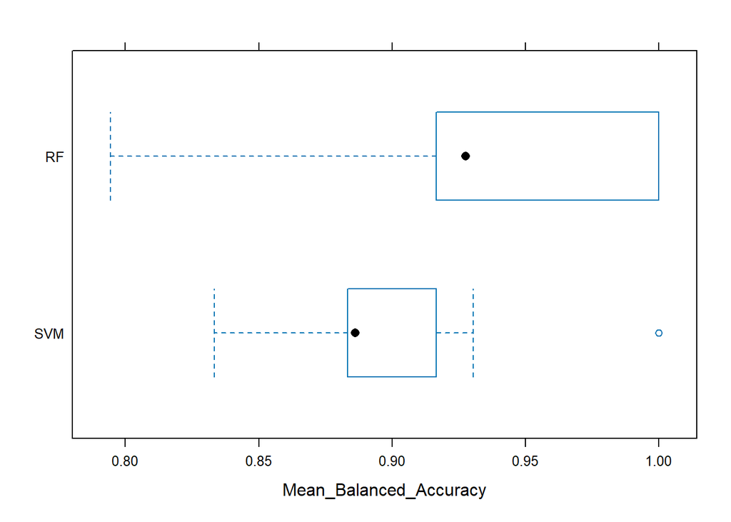

```r
bwplot(practica.resample, metric = "Mean_Balanced_Accuracy")
```

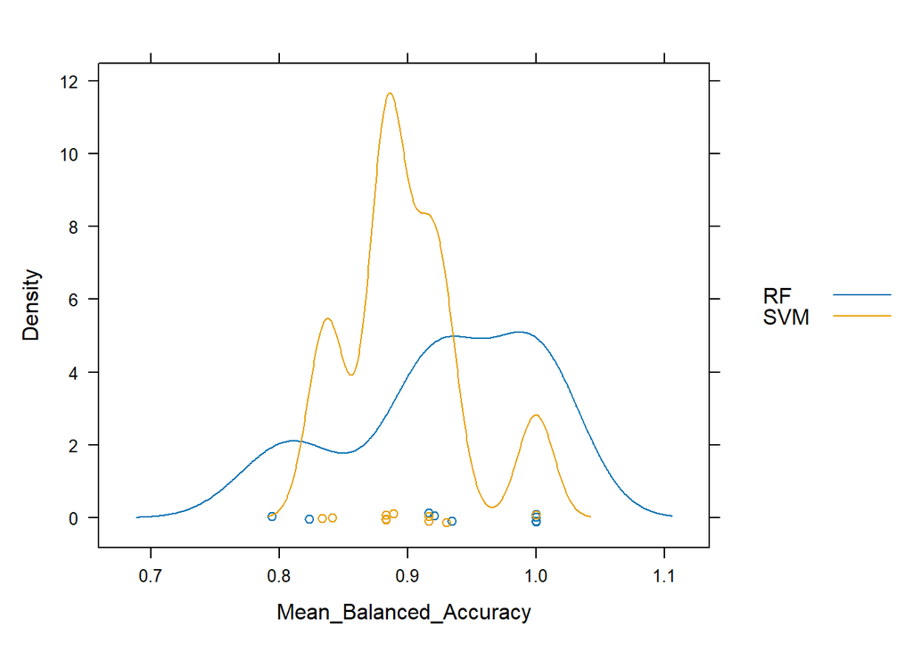

```r
densityplot(practica.resample, metric = "Mean_Balanced_Accuracy", auto.key = TRUE)
```